# SR_04_RLTD_ORG_CORP_ADDR_CITY

Related organization city · Text report

## Overview

**Description**

Address Foreign - City

**Table**

`SR-P04-T01-ID-RLTD-ORGS-TAXABLE-CORPORATION` (many)

**Location code**

`SCHED-R-PART-04-COL-A`

**Family**

`SCHED-R-PART-04-COL-A` · siblings: SR_04_RLTD_ORG_CORP_ADDR_CNTR, SR_04_RLTD_ORG_CORP_ADDR_L1, SR_04_RLTD_ORG_CORP_ADDR_L2, SR_04_RLTD_ORG_CORP_ADDR_STATE, SR_04_RLTD_ORG_CORP_ADDR_ZIP, SR_04_RLTD_ORG_CORP_EIN

**Data type**

text (xsd: TextType, CityType)

**Scope**

PC

**Status**

unreviewed

6

xpaths mapped (6 observed)

268,524

filings with a value

2009–2024

tax years observed

1

open flags (1 errors)

## Flags

| Severity | Flag | Xpath | Detail |
| --- | --- | --- | --- |
| ⚠ error | `COLLISION` | IRS990ScheduleR/IdRelatedOrgTxblCorpTrGrp/ForeignAddress/CityNm | 26200 filings contain 2+ of its xpaths; most common set: /Return/ReturnData/IRS990ScheduleR/IdRelatedOrgTxblCorpTrGrp/ForeignAddress/CityNm ; /Return/ReturnData/IRS990ScheduleR/IdRelatedOrgTxblCorpTrG… |

## Xpaths

All mapped xpaths (under /Return/ReturnData or /Return/ReturnHeader), oldest first. Charts label each series by its xpath.

| Xpath | Form | Chart label | First year | Last year | Versions | Filings | Repeats in |
| --- | --- | --- | --- | --- | --- | --- | --- |
| IRS990ScheduleR/Form990ScheduleRPartIV/AddressUS/City | Sched R | same | 2009 | 2012 | 17 | 40,944 | 51.8% |
| IRS990ScheduleR/Form990ScheduleRPartIV/AddressForeign/City | Sched R | same | 2009 | 2012 | 14 | 4,631 | 34.9% |
| IRS990ScheduleR/IdRelatedOrgTxblCorpTrGrp/USAddress/City | Sched R | same | 2013 | 2013 | 3 | 14,114 | 50.3% |
| IRS990ScheduleR/IdRelatedOrgTxblCorpTrGrp/ForeignAddress/City | Sched R | …90ScheduleR/IdRelatedOrgTxblCorpTrGrp/ForeignAddress/City | 2013 | 2013 | 3 | 1,682 | 42.6% |
| IRS990ScheduleR/IdRelatedOrgTxblCorpTrGrp/USAddress/CityNm | Sched R | same | 2014 | 2024 | 34 | 182,343 | 51.0% |
| IRS990ScheduleR/IdRelatedOrgTxblCorpTrGrp/ForeignAddress/CityNm | Sched R | …ScheduleR/IdRelatedOrgTxblCorpTrGrp/ForeignAddress/CityNm | 2014 | 2024 | 33 | 24,810 | 41.2% |

## Coverage

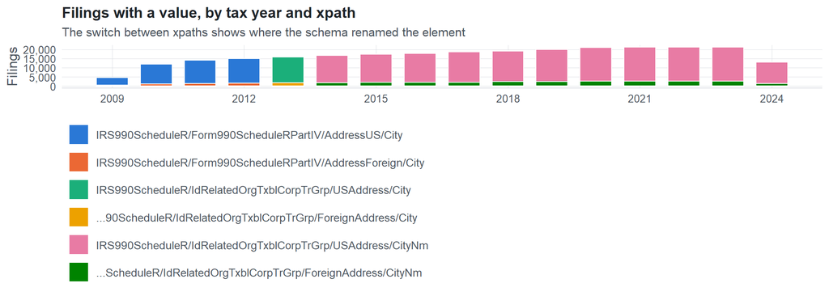

**Table view**

Table view: filings by tax year and series

| Tax year | IRS990ScheduleR/Form990ScheduleRPartIV/AddressUS/City | IRS990ScheduleR/Form990ScheduleRPartIV/AddressForeign/City | IRS990ScheduleR/IdRelatedOrgTxblCorpTrGrp/USAddress/City | …90ScheduleR/IdRelatedOrgTxblCorpTrGrp/ForeignAddress/City | IRS990ScheduleR/IdRelatedOrgTxblCorpTrGrp/USAddress/CityNm | …ScheduleR/IdRelatedOrgTxblCorpTrGrp/ForeignAddress/CityNm |
| --- | --- | --- | --- | --- | --- | --- |
| 2009 | 4,167 | 523 | 0 | 0 | 0 | 0 |
| 2010 | 10,720 | 1,158 | 0 | 0 | 0 | 0 |
| 2011 | 12,659 | 1,403 | 0 | 0 | 0 | 0 |
| 2012 | 13,398 | 1,547 | 0 | 0 | 0 | 0 |
| 2013 | 0 | 0 | 14,114 | 1,682 | 0 | 0 |
| 2014 | 0 | 0 | 0 | 0 | 14,930 | 1,853 |
| 2015 | 0 | 0 | 0 | 0 | 15,444 | 1,989 |
| 2016 | 0 | 0 | 0 | 0 | 15,775 | 2,049 |
| 2017 | 0 | 0 | 0 | 0 | 16,561 | 2,080 |
| 2018 | 0 | 0 | 0 | 0 | 16,741 | 2,420 |
| 2019 | 0 | 0 | 0 | 0 | 17,305 | 2,527 |
| 2020 | 0 | 0 | 0 | 0 | 18,341 | 2,651 |
| 2021 | 0 | 0 | 0 | 0 | 18,550 | 2,591 |
| 2022 | 0 | 0 | 0 | 0 | 18,640 | 2,654 |
| 2023 | 0 | 0 | 0 | 0 | 18,431 | 2,690 |
| 2024 | 0 | 0 | 0 | 0 | 11,625 | 1,306 |

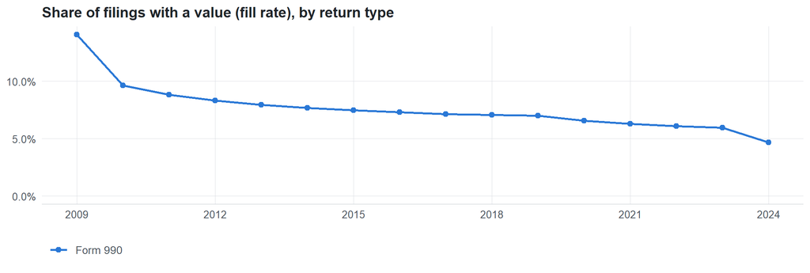

**Table view**

Table view: fill rate

| Tax year | Return type | Filings | All filings | Fill rate |
| --- | --- | --- | --- | --- |
| 2009 | Form 990 | 4,690 | 33,311 | 14.08% |
| 2010 | Form 990 | 11,878 | 123,025 | 9.65% |
| 2011 | Form 990 | 14,062 | 159,504 | 8.82% |
| 2012 | Form 990 | 14,945 | 179,688 | 8.32% |
| 2013 | Form 990 | 15,796 | 198,855 | 7.94% |
| 2014 | Form 990 | 16,783 | 218,619 | 7.68% |
| 2015 | Form 990 | 17,433 | 233,519 | 7.47% |
| 2016 | Form 990 | 17,824 | 243,903 | 7.31% |
| 2017 | Form 990 | 18,641 | 261,612 | 7.13% |
| 2018 | Form 990 | 19,161 | 271,442 | 7.06% |
| 2019 | Form 990 | 19,832 | 283,694 | 6.99% |
| 2020 | Form 990 | 20,992 | 320,342 | 6.55% |
| 2021 | Form 990 | 21,141 | 336,480 | 6.28% |
| 2022 | Form 990 | 21,294 | 349,055 | 6.10% |
| 2023 | Form 990 | 21,121 | 354,768 | 5.95% |
| 2024 | Form 990 | 12,931 | 277,298 | 4.66% |

## Repeating groups

Table cardinality in the concordance: **many**. 6 of 6 observed xpaths repeat within a filing.

Repeating element each xpath was observed in (from the raw indexed xpath)

| Xpath | Repeating element | Filings (summed over years) |
| --- | --- | --- |
| IRS990ScheduleR/Form990ScheduleRPartIV/AddressForeign/City | (none) | 370 |
| IRS990ScheduleR/Form990ScheduleRPartIV/AddressForeign/City | IRS990ScheduleR/Form990ScheduleRPartIV | 4261 |
| IRS990ScheduleR/Form990ScheduleRPartIV/AddressUS/City | (none) | 18843 |
| IRS990ScheduleR/Form990ScheduleRPartIV/AddressUS/City | IRS990ScheduleR/Form990ScheduleRPartIV | 22101 |
| IRS990ScheduleR/IdRelatedOrgTxblCorpTrGrp/ForeignAddress/City | (none) | 150 |
| IRS990ScheduleR/IdRelatedOrgTxblCorpTrGrp/ForeignAddress/City | IRS990ScheduleR/IdRelatedOrgTxblCorpTrGrp | 1532 |
| IRS990ScheduleR/IdRelatedOrgTxblCorpTrGrp/USAddress/City | (none) | 6705 |
| IRS990ScheduleR/IdRelatedOrgTxblCorpTrGrp/USAddress/City | IRS990ScheduleR/IdRelatedOrgTxblCorpTrGrp | 7409 |
| IRS990ScheduleR/IdRelatedOrgTxblCorpTrGrp/ForeignAddress/CityNm | (none) | 2467 |
| IRS990ScheduleR/IdRelatedOrgTxblCorpTrGrp/ForeignAddress/CityNm | IRS990ScheduleR/IdRelatedOrgTxblCorpTrGrp | 22343 |
| IRS990ScheduleR/IdRelatedOrgTxblCorpTrGrp/USAddress/CityNm | (none) | 85289 |
| IRS990ScheduleR/IdRelatedOrgTxblCorpTrGrp/USAddress/CityNm | IRS990ScheduleR/IdRelatedOrgTxblCorpTrGrp | 97054 |

## Values

| Result | Check | Detail |
| --- | --- | --- |
| ✓ pass | Values are text, not numbers | 0% of values are numeric |
| ⓘ info | No sign of truncation | IRS990ScheduleR/Form990ScheduleRPartIV/AddressForeign/City: longest value is exactly 35 characters; …90ScheduleR/IdRelatedOrgTxblCorpTrGrp/ForeignAddress/City: longest value is exactly 35 characters |
| ⓘ info | No dominant boilerplate value | most common value covers 39% of filings: “GRAND CAYMAN” |

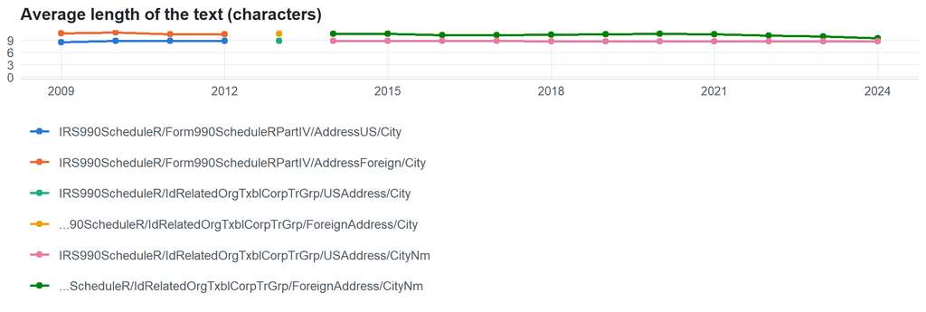

**Table view**

Table view: length and variety by tax year

| Series | Tax year | Filings | Avg length | Max length | Distinct values (approx.) |
| --- | --- | --- | --- | --- | --- |
| IRS990ScheduleR/Form990ScheduleRPartIV/AddressUS/City | 2009 | 4,167 | 8 | 22 | 1,339 |
| IRS990ScheduleR/Form990ScheduleRPartIV/AddressUS/City | 2010 | 10,720 | 9 | 22 | 1,624 |
| IRS990ScheduleR/Form990ScheduleRPartIV/AddressUS/City | 2011 | 12,659 | 9 | 22 | 5,175 |
| IRS990ScheduleR/Form990ScheduleRPartIV/AddressUS/City | 2012 | 13,398 | 9 | 22 | 4,821 |
| IRS990ScheduleR/Form990ScheduleRPartIV/AddressForeign/City | 2009 | 523 | 11 | 33 | 222 |
| IRS990ScheduleR/Form990ScheduleRPartIV/AddressForeign/City | 2010 | 1,158 | 11 | 35 | 341 |
| IRS990ScheduleR/Form990ScheduleRPartIV/AddressForeign/City | 2011 | 1,403 | 10 | 35 | 335 |
| IRS990ScheduleR/Form990ScheduleRPartIV/AddressForeign/City | 2012 | 1,547 | 10 | 35 | 405 |
| IRS990ScheduleR/IdRelatedOrgTxblCorpTrGrp/USAddress/City | 2013 | 14,114 | 9 | 22 | 3,708 |
| …90ScheduleR/IdRelatedOrgTxblCorpTrGrp/ForeignAddress/City | 2013 | 1,682 | 11 | 35 | 424 |
| IRS990ScheduleR/IdRelatedOrgTxblCorpTrGrp/USAddress/CityNm | 2014 | 14,930 | 9 | 22 | 3,170 |
| IRS990ScheduleR/IdRelatedOrgTxblCorpTrGrp/USAddress/CityNm | 2015 | 15,444 | 9 | 22 | 3,474 |
| IRS990ScheduleR/IdRelatedOrgTxblCorpTrGrp/USAddress/CityNm | 2016 | 15,775 | 9 | 22 | 5,089 |
| IRS990ScheduleR/IdRelatedOrgTxblCorpTrGrp/USAddress/CityNm | 2017 | 16,561 | 9 | 22 | 3,715 |
| IRS990ScheduleR/IdRelatedOrgTxblCorpTrGrp/USAddress/CityNm | 2018 | 16,741 | 9 | 22 | 4,070 |
| IRS990ScheduleR/IdRelatedOrgTxblCorpTrGrp/USAddress/CityNm | 2019 | 17,305 | 9 | 22 | 3,074 |
| IRS990ScheduleR/IdRelatedOrgTxblCorpTrGrp/USAddress/CityNm | 2020 | 18,341 | 9 | 22 | 4,062 |
| IRS990ScheduleR/IdRelatedOrgTxblCorpTrGrp/USAddress/CityNm | 2021 | 18,550 | 9 | 22 | 4,486 |
| IRS990ScheduleR/IdRelatedOrgTxblCorpTrGrp/USAddress/CityNm | 2022 | 18,640 | 9 | 22 | 4,784 |
| IRS990ScheduleR/IdRelatedOrgTxblCorpTrGrp/USAddress/CityNm | 2023 | 18,431 | 9 | 22 | 2,938 |
| IRS990ScheduleR/IdRelatedOrgTxblCorpTrGrp/USAddress/CityNm | 2024 | 11,625 | 9 | 22 | 2,712 |
| …ScheduleR/IdRelatedOrgTxblCorpTrGrp/ForeignAddress/CityNm | 2014 | 1,853 | 11 | 35 | 455 |
| …ScheduleR/IdRelatedOrgTxblCorpTrGrp/ForeignAddress/CityNm | 2015 | 1,989 | 11 | 43 | 488 |
| …ScheduleR/IdRelatedOrgTxblCorpTrGrp/ForeignAddress/CityNm | 2016 | 2,049 | 10 | 43 | 518 |
| …ScheduleR/IdRelatedOrgTxblCorpTrGrp/ForeignAddress/CityNm | 2017 | 2,080 | 10 | 43 | 713 |
| …ScheduleR/IdRelatedOrgTxblCorpTrGrp/ForeignAddress/CityNm | 2018 | 2,420 | 10 | 43 | 575 |
| …ScheduleR/IdRelatedOrgTxblCorpTrGrp/ForeignAddress/CityNm | 2019 | 2,527 | 10 | 43 | 722 |
| …ScheduleR/IdRelatedOrgTxblCorpTrGrp/ForeignAddress/CityNm | 2020 | 2,651 | 11 | 43 | 910 |
| …ScheduleR/IdRelatedOrgTxblCorpTrGrp/ForeignAddress/CityNm | 2021 | 2,591 | 10 | 43 | 913 |
| …ScheduleR/IdRelatedOrgTxblCorpTrGrp/ForeignAddress/CityNm | 2022 | 2,654 | 10 | 34 | 998 |
| …ScheduleR/IdRelatedOrgTxblCorpTrGrp/ForeignAddress/CityNm | 2023 | 2,690 | 10 | 34 | 814 |
| …ScheduleR/IdRelatedOrgTxblCorpTrGrp/ForeignAddress/CityNm | 2024 | 1,306 | 9 | 35 | 758 |

Most common values by xpath (all years; long values truncated)

| Series | Value | Filings | Share |
| --- | --- | --- | --- |
| IRS990ScheduleR/Form990ScheduleRPartIV/AddressUS/City | NEW YORK | 1,420 | 3.5% |
| IRS990ScheduleR/Form990ScheduleRPartIV/AddressUS/City | COLUMBUS | 1,070 | 2.6% |
| IRS990ScheduleR/Form990ScheduleRPartIV/AddressUS/City | ST LOUIS | 973 | 2.4% |
| IRS990ScheduleR/Form990ScheduleRPartIV/AddressUS/City | CLEVELAND | 886 | 2.2% |
| IRS990ScheduleR/Form990ScheduleRPartIV/AddressUS/City | WARREN | 775 | 1.9% |
| IRS990ScheduleR/Form990ScheduleRPartIV/AddressUS/City | SAN ANTONIO | 703 | 1.7% |
| IRS990ScheduleR/Form990ScheduleRPartIV/AddressUS/City | ALEXANDRIA | 682 | 1.7% |
| IRS990ScheduleR/Form990ScheduleRPartIV/AddressUS/City | SOUTHFIELD | 629 | 1.5% |
| IRS990ScheduleR/Form990ScheduleRPartIV/AddressUS/City | CHICAGO | 520 | 1.3% |
| IRS990ScheduleR/Form990ScheduleRPartIV/AddressUS/City | Denver | 308 | 0.8% |
| IRS990ScheduleR/Form990ScheduleRPartIV/AddressUS/City | DENVER | 213 | 0.5% |
| IRS990ScheduleR/Form990ScheduleRPartIV/AddressUS/City | NIAGARA FALLS | 205 | 0.5% |
| IRS990ScheduleR/Form990ScheduleRPartIV/AddressUS/City | DUBLIN | 190 | 0.5% |
| IRS990ScheduleR/Form990ScheduleRPartIV/AddressUS/City | Burlington | 109 | 0.3% |
| IRS990ScheduleR/Form990ScheduleRPartIV/AddressUS/City | Lexington | 104 | 0.3% |
| IRS990ScheduleR/Form990ScheduleRPartIV/AddressUS/City | Little Rock | 104 | 0.3% |
| IRS990ScheduleR/Form990ScheduleRPartIV/AddressUS/City | Englewood | 103 | 0.3% |
| IRS990ScheduleR/Form990ScheduleRPartIV/AddressUS/City | Chattanooga | 102 | 0.2% |
| IRS990ScheduleR/Form990ScheduleRPartIV/AddressUS/City | Tacoma | 101 | 0.2% |
| IRS990ScheduleR/Form990ScheduleRPartIV/AddressUS/City | Towson | 101 | 0.2% |
| IRS990ScheduleR/Form990ScheduleRPartIV/AddressUS/City | Denville | 100 | 0.2% |
| IRS990ScheduleR/Form990ScheduleRPartIV/AddressUS/City | Des Moines | 100 | 0.2% |
| IRS990ScheduleR/Form990ScheduleRPartIV/AddressForeign/City | GRAND CAYMAN | 1,196 | 25.8% |
| IRS990ScheduleR/Form990ScheduleRPartIV/AddressForeign/City | Grand Cayman | 920 | 19.9% |
| IRS990ScheduleR/Form990ScheduleRPartIV/AddressForeign/City | HAMILTON | 550 | 11.9% |
| IRS990ScheduleR/Form990ScheduleRPartIV/AddressForeign/City | GEORGETOWN | 521 | 11.3% |
| IRS990ScheduleR/Form990ScheduleRPartIV/AddressForeign/City | Hamilton | 508 | 11.0% |
| IRS990ScheduleR/Form990ScheduleRPartIV/AddressForeign/City | GEORGE TOWN | 135 | 2.9% |
| IRS990ScheduleR/Form990ScheduleRPartIV/AddressForeign/City | LONDON | 113 | 2.4% |
| IRS990ScheduleR/Form990ScheduleRPartIV/AddressForeign/City | EBENE CYBERCITY | 83 | 1.8% |

First rows shown.

## Examples

| Tax year | Return | Xpath | Organization | Value | Source |
| --- | --- | --- | --- | --- | --- |
| 2024 | 990 | IRS990ScheduleR/IdRelatedOrgTxblCorpTrGrp/ForeignAddress/CityNm | AVMED INC | GRAND CAYMAN | [XML](https://gt990datalake-rawdata.s3.amazonaws.com/EfileData/XmlFiles/202533099349303308_public.xml) |
| 2024 | 990 | IRS990ScheduleR/IdRelatedOrgTxblCorpTrGrp/USAddress/CityNm | THE CLEVELAND CLINIC FOUNDATION | CLEVELAND | [XML](https://gt990datalake-rawdata.s3.amazonaws.com/EfileData/XmlFiles/202513189349302136_public.xml) |
| 2023 | 990 | IRS990ScheduleR/IdRelatedOrgTxblCorpTrGrp/ForeignAddress/CityNm | THE BROOKINGS INSTITUTION | NEW DELHI | [XML](https://gt990datalake-rawdata.s3.amazonaws.com/EfileData/XmlFiles/202531349349306718_public.xml) |
| 2023 | 990 | IRS990ScheduleR/IdRelatedOrgTxblCorpTrGrp/USAddress/CityNm | AK Steel Corp VEBA UAW Retirees | WEST CHESTER TOWNSHIP | [XML](https://gt990datalake-rawdata.s3.amazonaws.com/EfileData/XmlFiles/202442269349300844_public.xml) |
| 2022 | 990 | IRS990ScheduleR/IdRelatedOrgTxblCorpTrGrp/ForeignAddress/CityNm | INSURANCE INFORMATION INSTITUTE INC | HOUNDSDITCH | [XML](https://gt990datalake-rawdata.s3.amazonaws.com/EfileData/XmlFiles/202332649349300223_public.xml) |
| 2022 | 990 | IRS990ScheduleR/IdRelatedOrgTxblCorpTrGrp/USAddress/CityNm | Providence Brown Street Housing | Rochester | [XML](https://gt990datalake-rawdata.s3.amazonaws.com/EfileData/XmlFiles/202411239349300546_public.xml) |
| 2021 | 990 | IRS990ScheduleR/IdRelatedOrgTxblCorpTrGrp/ForeignAddress/CityNm | LAKEVILLE SURGERY PC | Hamilton | [XML](https://gt990datalake-rawdata.s3.amazonaws.com/EfileData/XmlFiles/202243189349301614_public.xml) |
| 2021 | 990 | IRS990ScheduleR/IdRelatedOrgTxblCorpTrGrp/USAddress/CityNm | St John Providence | ST LOUIS | [XML](https://gt990datalake-rawdata.s3.amazonaws.com/EfileData/XmlFiles/202311329349304191_public.xml) |
| 2020 | 990 | IRS990ScheduleR/IdRelatedOrgTxblCorpTrGrp/ForeignAddress/CityNm | EVERSIGHT INTERNATIONAL | GUMCHEONGU SEOUL | [XML](https://gt990datalake-rawdata.s3.amazonaws.com/EfileData/XmlFiles/202121759349300507_public.xml) |
| 2020 | 990 | IRS990ScheduleR/IdRelatedOrgTxblCorpTrGrp/USAddress/CityNm | American Agents Alliance Inc | Sacramento | [XML](https://gt990datalake-rawdata.s3.amazonaws.com/EfileData/XmlFiles/202102219349302160_public.xml) |
| 2019 | 990 | IRS990ScheduleR/IdRelatedOrgTxblCorpTrGrp/ForeignAddress/CityNm | BAYLOR COLLEGE OF MEDICINE INTERNATIONAL | PO BOX NEUQUEN | [XML](https://gt990datalake-rawdata.s3.amazonaws.com/EfileData/XmlFiles/202131379349304643_public.xml) |
| 2019 | 990 | IRS990ScheduleR/IdRelatedOrgTxblCorpTrGrp/USAddress/CityNm | BAPTIST BESTHEALTH INC | MEMPHIS | [XML](https://gt990datalake-rawdata.s3.amazonaws.com/EfileData/XmlFiles/202112259349301966_public.xml) |

## Reviewer checklist

- The definition matches the form line and instructions for every xpath’s schema years.
- Every xpath pooled here measures the same thing on the 990 and 990-EZ (close enough for analysis).
- The coverage chart has no unexplained gaps or jumps between tax years.
- Each open flag is fixed, or accepted with a note in validation_log.csv.
- Values answer the question on the form line (not another line’s explanation).
- Boilerplate such as ‘See Schedule O’ or ‘N/A’ is expected here, or should be treated as missing.
- Text that is really a number or a code is flagged for a different data type.

Record the review as a row in `inst/extdata/src/validation_log.csv` (variable_name, reviewer, date, status, note). Evidence built 2026-09-23 17:09:04 MST from the ef2 DuckDB builds (tax years 2009–2024).